# IBM HR Employee Attrition

### Bivariate and Multivariate analysis

```python
#Crosstab
pd.crosstab(df['OverTime'], df['Attrition'], normalize = 'index')
```

| Attrition OverTime | No | Yes |
| --- | --- | --- |
| No | 0.895636 | 0.104364 |
| Yes | 0.694712 | 0.305288 |

```python
# How many employees do not work over time and have not left the company

df[(df['OverTime'] == 'No') & (df['Attrition'] == 'No')].shape
```

```
(944, 31)
```

```python
# #mployes who do not work over time but still left the company

df[(df['OverTime'] == 'No') & (df['Attrition'] == 'Yes')].shape
```

```
(110, 31)
```

```python
# Proportion of employees who do not work overtime, but still left the company
110/(944 + 110)
```

```
0.10436432637571158
```

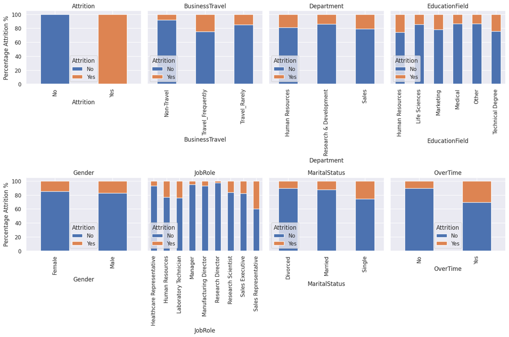

```python
fig, axes = plt.subplots(nrows=2, ncols=4, figsize=(15, 10), sharey=True)

i = 0
for x in range(2):
    for y in range(4):
        if i < len(cat_cols):
            pd.crosstab(df[cat_cols[i]], df['Attrition'], normalize='index')\
              .mul(100).plot(kind='bar', stacked=True, ax=axes[x, y])
            axes[x, y].set_ylabel('Percentage Attrition %')
            axes[x, y].set_title(cat_cols[i])
            i += 1
        else:
            axes[x, y].axis('off')  # Hide empty subplot

plt.tight_layout()
plt.show()
```

Relationship between attrition and Numerical variables

```python
# The mean of numerical variables grouped by attrition
df.groupby(['Attrition'])[num_cols].mean()
```

| Attrition | Age | DailyRate | DistanceFromHome | Education | EnvironmentSatisfaction | HourlyRate | JobInvolvement | JobLevel | JobSatisfaction | MonthlyIncome | ... | PerformanceRating | RelationshipSatisfaction | StockOptionLevel | TotalWorkingYears | TrainingTimesLastYear | WorkLifeBalance | YearsAtCompany | YearsInCurrentRole | YearsSinceLastPromotion | YearsWithCurrManager |
| --- | --- | --- | --- | --- | --- | --- | --- | --- | --- | --- | --- | --- | --- | --- | --- | --- | --- | --- | --- | --- | --- |
| No | 37.561233 | 812.504461 | 8.915653 | 2.927007 | 2.771290 | 65.952149 | 2.770479 | 2.145985 | 2.778589 | 6832.739659 | ... | 3.153285 | 2.733982 | 0.845093 | 11.862936 | 2.832928 | 2.781022 | 7.369019 | 4.484185 | 2.234388 | 4.367397 |
| Yes | 33.607595 | 750.362869 | 10.632911 | 2.839662 | 2.464135 | 65.573840 | 2.518987 | 1.637131 | 2.468354 | 4787.092827 | ... | 3.156118 | 2.599156 | 0.527426 | 8.244726 | 2.624473 | 2.658228 | 5.130802 | 2.902954 | 1.945148 | 2.852321 |

2 rows × 23 columns

- Observations
  - **Age**: Employees who left are younger (33.6 vs 37.6).
  - **MonthlyIncome**: Those who left earned significantly less (≈ $4.8k vs $6.8k).
  - **JobLevel**: Leavers tend to be in lower-level positions (1.64 vs 2.15).
  - **TotalWorkingYears**: Lower average experience for leavers (8.2 vs 11.9).
  - **YearsWithCurrManager**: Much lower for leavers (2.85 vs 4.37), possibly indicating weak leadership ties.
  - **YearsInCurrentRole**: Leavers had shorter tenure in role (2.9 vs 4.5).
  - **JobInvolvement & Satisfaction Scores**: Lower across the board for leavers (e.g., JobSatisfaction: 2.47 vs 2.78).
  - **EnvironmentSatisfaction**: Lower among those who left (2.46 vs 2.77).
  - **DistanceFromHome**: Higher for leavers (10.6 vs 8.9) — long commutes may affect attrition.
  - **StockOptionLevel**: Higher for those who stayed (0.85 vs 0.53) — equity may help retain talent.
- Find out what kind of employees are leaving the company more

Relationship between different numerical variables

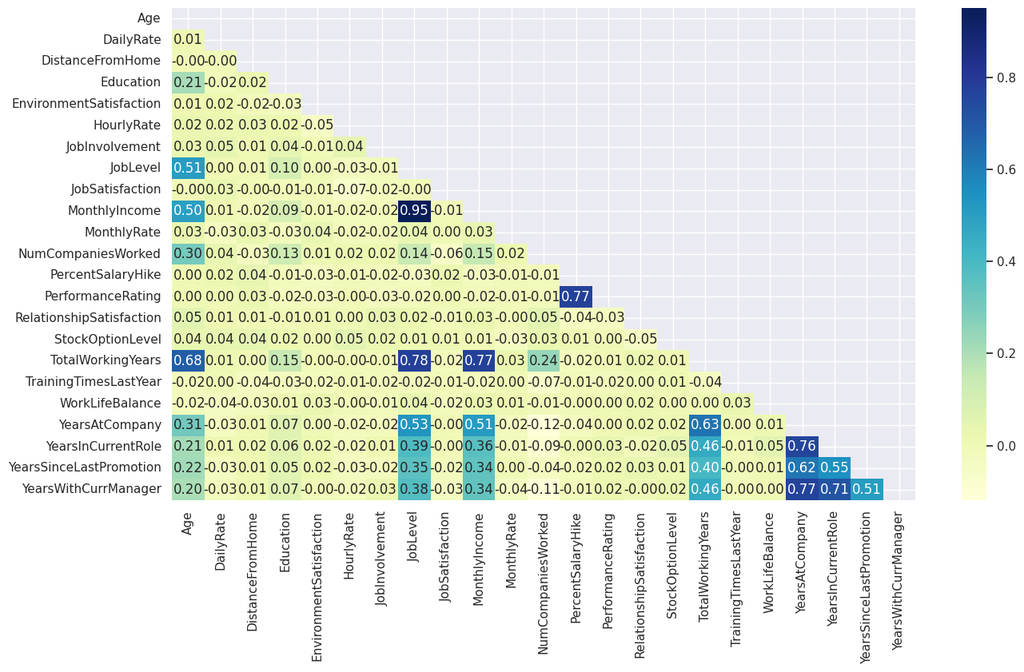

```python
# Plotting the correlation between numerical variables
plt.figure(figsize = (15, 8))

mask = np.triu(df[num_cols].corr())
sns.heatmap(df[num_cols].corr(), annot = True, fmt = '0.2f', cmap = 'YlGnBu', mask=mask)
```

## Model Building - Approach

1. Prepare the data for modeling.
2. Partition the data into train and test sets.
3. Build the model on the train data.
4. Tune the model if required.
5. Test the data on the test set.

### Preparing data for modeling

```python
#replace values in a pandas DataFrame

#Method 1
#df['OverTime'].replace({'Yes': 1, 'No': 0})

#Method 2
np.where(df['OverTime'] == 'Yes', 1, 0)
  # This checks for each value in the OverTime column if it is equal to 'Yes'
  # If the condition is True, it assigns 1, otherwise 0 is assigned
```

```
array([1, 0, 1, ..., 1, 0, 0])
```

```python
# Creating dummy variables for categorical Variables

# Creating the list of columns for which we need to create the dummy variables
to_get_dummies_for = ['BusinessTravel', 'Department', 'Education', 'EducationField', 'EnvironmentSatisfaction', 'Gender', 'JobInvolvement',
                      'JobLevel', 'JobRole', 'MaritalStatus']

# Creating dummy variables
df = pd.get_dummies(data = df, columns = to_get_dummies_for, drop_first = True)

# Mapping overtime and attrition
dict_OverTime = {'Yes': 1, 'No': 0} # just like above (created to map categorical string values ('Yes' and 'No') into numeric values (1 and 0)
dict_attrition = {'Yes': 1, 'No': 0}

df['OverTime'] = df.OverTime.map(dict_OverTime) # maps the 'OverTime' column's values ('Yes' to 1, 'No' to 0).
df['Attrition'] = df.Attrition.map(dict_attrition)
```

```python
# Separating the independent variables (X) and the dependent variable (Y)

# Separating the target variable and other variables
Y = df.Attrition
X = df.drop(columns = ['Attrition']) #target
```

```python
X.shape # training data
```

```
(1470, 54)
```

### Scaling Optoins and Ranking

```python
data = df.copy()
```

```python
from sklearn.preprocessing import (
    StandardScaler, MinMaxScaler, RobustScaler, MaxAbsScaler,
    PowerTransformer, QuantileTransformer, Normalizer
)

# 📌 Load dataset (Modify path if needed)
#file_path = "your_dataset.csv"  # Update with correct file
#data = pd.read_csv(file_path)

# 📌 Select numeric columns only
numeric_features = data.select_dtypes(include=['number']).dropna()

# 📌 Detect Outliers using IQR (Interquartile Range)
def detect_outliers(df1):
    outlier_info = {}
    for column in df1.columns:
        Q1 = df1[column].quantile(0.25)
        Q3 = df1[column].quantile(0.75)
        IQR = Q3 - Q1
        lower_bound = Q1 - 1.5 * IQR
        upper_bound = Q3 + 1.5 * IQR

        # Count outliers
        outlier_count = ((df1[column] < lower_bound) | (df1[column] > upper_bound)).sum()
        outlier_info[column] = outlier_count

    return outlier_info

outliers = detect_outliers(numeric_features)
outlier_df1 = pd.DataFrame.from_dict(outliers, orient='index', columns=['Outlier Count'])

# 📌 Check Skewness (to determine if transformation is needed)
skewness = numeric_features.skew()

# 📌 Scaling Options with All Variants
scalers = {
    "StandardScaler": StandardScaler(),
    "MinMaxScaler": MinMaxScaler(),
    "RobustScaler": RobustScaler(),
    "MaxAbsScaler": MaxAbsScaler(),
    "PowerTransformer (Yeo-Johnson)": PowerTransformer(method="yeo-johnson"),
    "PowerTransformer (Box-Cox)": PowerTransformer(method="box-cox"),
    "QuantileTransformer (Normal)": QuantileTransformer(output_distribution="normal"),
    "QuantileTransformer (Uniform)": QuantileTransformer(output_distribution="uniform"),
    "Normalizer (L1)": Normalizer(norm="l1"),
    "Normalizer (L2)": Normalizer(norm="l2"),
    "Normalizer (Max)": Normalizer(norm="max"),
}

scaler_results = {}

# 📌 Try all scalers & transformations
for scaler_name, scaler in scalers.items():
    try:
        transformed_data = scaler.fit_transform(numeric_features)
        transformed_df1 = pd.DataFrame(transformed_data, columns=numeric_features.columns, index=numeric_features.index)

        # Calculate variance after scaling (Higher is better)
        cumulative_variance = transformed_df1.var().sum()
        scaler_results[scaler_name] = cumulative_variance

    except Exception as e:
        print(f"❌ Error with {scaler_name}: {e}")

# 📌 Convert results to DataFrame and Rank
scaler_rank_df1 = pd.DataFrame(list(scaler_results.items()), columns=['Scaler', 'Cumulative Variance'])
scaler_rank_df1 = scaler_rank_df1.sort_values(by="Cumulative Variance", ascending=False)

# 📌 Pick the best scaler based on variance ranking
best_scaler_name = scaler_rank_df1.iloc[0]["Scaler"]
best_scaler = scalers[best_scaler_name]
scaled_data = best_scaler.fit_transform(numeric_features)

# 📌 Convert Scaled Data to DataFrame
scaled_df1 = pd.DataFrame(scaled_data, columns=numeric_features.columns, index=numeric_features.index)

# 📌 Save the scaled dataset
scaled_df1.to_csv("/content/drive/MyDrive/My DS DA/Employee Attrition/scaled_dataset.csv", index=False)

# 📌 Explain Selection
explanations = {
    "MinMaxScaler": "Scales data between [0,1]. Used in Unsupervised Learning & Deep Learning but NOT recommended for outliers.",
    "StandardScaler": "Standardizes data to mean=0, variance=1. Recommended for Unsupervised Learning & Deep Learning. Works well with outliers.",
    "RobustScaler": "Uses median and IQR. Best choice for handling outliers in both Unsupervised and Supervised Learning.",
    "MaxAbsScaler": "Scales data between [-1,1]. Used for sparse data, not generally needed for typical datasets.",
    "PowerTransformer (Yeo-Johnson)": "Transforms data to be more Gaussian-like. Good for skewed data in Regression & Classification.",
    "PowerTransformer (Box-Cox)": "Similar to Yeo-Johnson but works only with strictly positive values. Reduces skewness.",
    "QuantileTransformer (Normal)": "Maps data to a normal distribution. Works well when distribution is unknown.",
    "QuantileTransformer (Uniform)": "Maps data to a uniform distribution. Useful for highly irregular distributions.",
    "Normalizer (L1)": "Normalizes each row by L1 norm. Good for text-based or sparse datasets.",
    "Normalizer (L2)": "Normalizes each row by L2 norm. Often used in clustering tasks.",
    "Normalizer (Max)": "Normalizes each row by its maximum absolute value. Good for text and sparse data."
}

# 📌 Print Summary
print("\n📊 Scaler Rankings:")
print(scaler_rank_df1)

print(f"\n🏆 Best Scaler Chosen: {best_scaler_name}")
print(f"📌 Reason: {explanations.get(best_scaler_name, 'No explanation available')}")

# 📌 Print Insights
if outlier_df1['Outlier Count'].sum() > 0:
    print("\n⚠️ Outliers detected! **RobustScaler** is recommended if handling them is critical.")
else:
    print("\n✅ No significant outliers detected. **StandardScaler** is the default recommendation.")

if any(abs(skewness) > 1):
    print("\n⚠️ Skewed data detected! **PowerTransformer**")
```

```
❌ Error with PowerTransformer (Box-Cox): The Box-Cox transformation can only be applied to strictly positive data

📊 Scaler Rankings:
                           Scaler  Cumulative Variance
5    QuantileTransformer (Normal)           135.841283
0                  StandardScaler            21.014295
4  PowerTransformer (Yeo-Johnson)            20.013615
2                    RobustScaler            11.679481
6   QuantileTransformer (Uniform)             2.197743
1                    MinMaxScaler             1.695346
3                    MaxAbsScaler             1.284149
9                Normalizer (Max)             0.135088
8                 Normalizer (L2)             0.098395
7                 Normalizer (L1)             0.060545

🏆 Best Scaler Chosen: QuantileTransformer (Normal)
📌 Reason: Maps data to a normal distribution. Works well when distribution is unknown.

⚠️ Outliers detected! **RobustScaler** is recommended if handling them is critical.

⚠️ Skewed data detected! **PowerTransformer**
```